# Growth-defense trade-off article analyses

### Percent herbivory (subset)

Here we compare the amount of herbivory as a percentage of leaf area between species for a random subset of wild plants in 2019 and 2022. First, we plot the data.

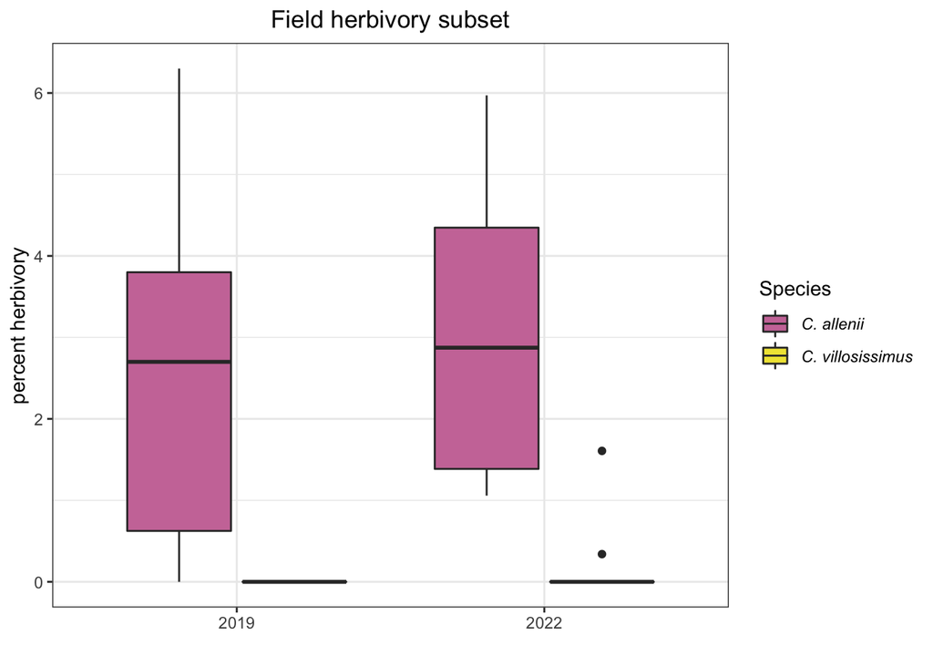

```r
# Read in the 2019 data (refresh)
Wherb19 <- read.csv("vill-all_RLB-herbivory_data_2019-Herbivory.csv", header=TRUE)

# select random subset for herbivory percent analysis
set.seed(1) # use 1 to match paper
Wherb19_subset <- Wherb19 %>%
  group_by(species) %>%
  sample_n(10)

# # Non-parametric test of 2019 only
# wilcox.test(Wherb19_subset$per_herbivory ~ Wherb19_subset$species) # W = 90, p-value = 0.0007512
# ## MEANS:  allenii - 2.54; vill - 0.00
# #t.test(Wherb19_subset$per_herbivory ~ Wherb19_subset$species)
# # t = 3.7367, df = 9, p-value = 0.004649 - differs in signif. use wilcox as appropriate for non-normal data

# Read in the 2022 data
Wherb22_subset <- read.csv("2022_Wild_Percent_Herbivory_subset.csv", header = T)

# # Non-parametric test of 2022 data only
# wilcox.test(Wherb22_subset$ave_per_herb ~ Wherb22_subset$spp) # W = 96, p-value = 0.0003801
# ## MEANS:  allenii - 3.055  ; vill - 0.1947
# t.test(Wherb22_subset$ave_per_herb ~ Wherb22_subset$spp)
# # t = 4.873, df = 10.446, p-value = 0.0005718 -> use wilcox as appropriate for non-normal data

# 2019/2022 combined
Wherb19_subset$year <- '2019'
Wherb22_subset$year <- '2022'
names(Wherb19_subset) <- c("date","ID", "spp", "ave_per_herb", "year")
Wherb_full_subset <- Wherb22_subset %>%
  dplyr::select(spp,ave_per_herb,year) %>%
  full_join((Wherb19_subset %>% dplyr::select( "spp", "ave_per_herb", "year")),.)

# plotting subset data
# plot of herbivory subset data - probably not for inclusion #
ggplot(data=Wherb_full_subset, aes(x=year, y=ave_per_herb)) +
  geom_boxplot(aes(fill = spp)) +
  scale_fill_manual(values = c("#cc79a7", "#f0e442"), name = "Species",
                    labels=c("alle" = expression(italic("C. allenii")),
                             "vill" = expression(italic("C. villosissimus")))) +
  theme(plot.title = element_text(hjust = 0.5), legend.text.align = 0) +
  ggtitle("Field herbivory subset") +
  xlab("") +
  ylab("percent herbivory")+
  scale_x_discrete(labels=c("alle" = expression(italic("C. allenii")),
                            "vill" = expression(italic("C. villosissimus"))))
```

```r
# ggsave("wild_per_herbivory_plot.png", device = "png", width = 10, height = 8, units = "cm")
```

Here we poke at the data with some stats… Not sure what is best here. All analyses say what is pretty obvious from the plot: percent herbivory clearly varies by species, but likely due to 0s, and does not clearly vary here between years - I think this is an artifact of taking a small subset. Beetles generally seem to eat similar (though highly variable) amounts in each year once they get to a suitible plant - they just find fewer suitable plants in drier years (fewer nice moist rolled leaves).

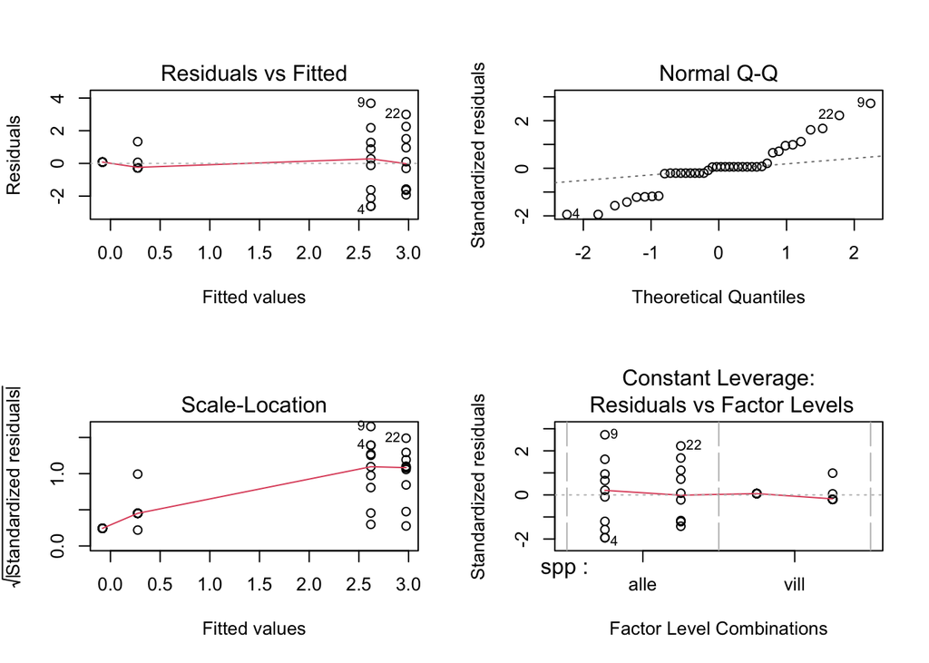

```r
# INCOMPLETE: some analyses...
# Testing model assumptions
# visual assesssment
lm <- lm(ave_per_herb ~ spp + year, data = Wherb_full_subset)
par(mfrow=c(2,2))
plot(lm) # not great - definitely not a normal Q-Q plot, unequal variance btw alle and vill
```

```r
# homoscedasticity statistical test
library(car)
ncvTest(lm) # bad... linear regression feels like a really bad idea.
```

```
Non-constant Variance Score Test
Variance formula: ~ fitted.values
Chisquare = 16.4147, Df = 1, p = 5.0889e-05
```

```r
summary(lm) # reasonable seeming results... year not popping, but makes sense since it was a weaker effect (though still very strong) in the presence absence data
```

```
Call:
lm(formula = ave_per_herb ~ spp + year, data = Wherb_full_subset)

Residuals:
    Min      1Q  Median      3Q     Max
-2.6200 -0.2747  0.0800  0.1474  3.6800

Coefficients:
            Estimate Std. Error t value Pr(>|t|)
(Intercept)   2.6200     0.3843   6.818 4.96e-08 ***
sppvill      -2.7000     0.4437  -6.085 4.81e-07 ***
year2022      0.3547     0.4437   0.800    0.429
---
Signif. codes:  0 '***' 0.001 '**' 0.01 '*' 0.05 '.' 0.1 ' ' 1

Residual standard error: 1.403 on 37 degrees of freedom
Multiple R-squared:  0.5045,    Adjusted R-squared:  0.4777
F-statistic: 18.83 on 2 and 37 DF,  p-value: 2.284e-06
```

```r
# two way anova to look at the impact of species and year on herbivory
aov2 <- aov(ave_per_herb ~ spp + year, data = Wherb_full_subset)
summary(aov2) # species significant but not year.
```

```
            Df Sum Sq Mean Sq F value   Pr(>F)
spp          1  72.90   72.90  37.030 4.81e-07 ***
year         1   1.26    1.26   0.639    0.429
Residuals   37  72.84    1.97
---
Signif. codes:  0 '***' 0.001 '**' 0.01 '*' 0.05 '.' 0.1 ' ' 1
```

```r
# 2 non-parametric mean comparisons.
wilcox.test(ave_per_herb ~ spp, data = Wherb_full_subset) #W = 372, p-value = 7.095e-07
```

```
    Wilcoxon rank sum test with continuity correction

data:  ave_per_herb by spp
W = 372, p-value = 7.095e-07
alternative hypothesis: true location shift is not equal to 0
```

```r
wilcox.test(ave_per_herb ~ year, data = Wherb_full_subset) #W = 165, p-value = 0.3185
```

```
    Wilcoxon rank sum test with continuity correction

data:  ave_per_herb by year
W = 165, p-value = 0.3185
alternative hypothesis: true location shift is not equal to 0
```

## Leaf toughness

```r
# read in the data
tough <- read.csv("leaf.toughness.csv", header = TRUE)

alle.tough <- tough[tough$species =="alle",] # subsetting alle toughness data
vill.tough <- tough[tough$species =="vill",] # subsetting vill toughness data
shapiro.test(alle.tough$ave) # not normally distributed (tough leaves spike)
```

```
    Shapiro-Wilk normality test

data:  alle.tough$ave
W = 0.85313, p-value = 0.009493
```

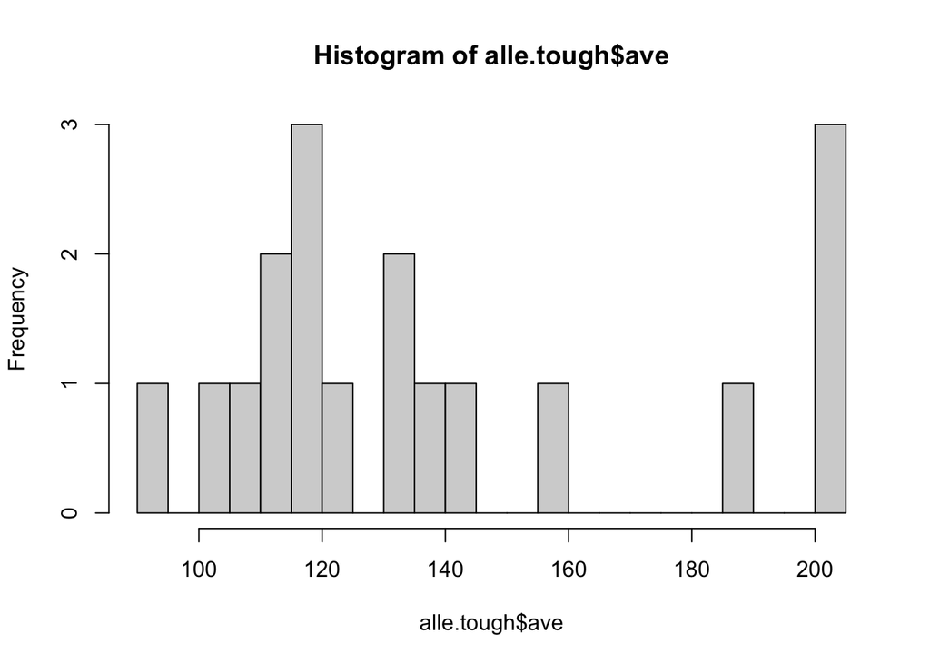

```r
hist(alle.tough$ave, breaks=20)
```

```r
shapiro.test(vill.tough$ave) # not normally distributed, but sorta close; p-value = 0.0765
```

```
    Shapiro-Wilk normality test

data:  vill.tough$ave
W = 0.91415, p-value = 0.0765
```

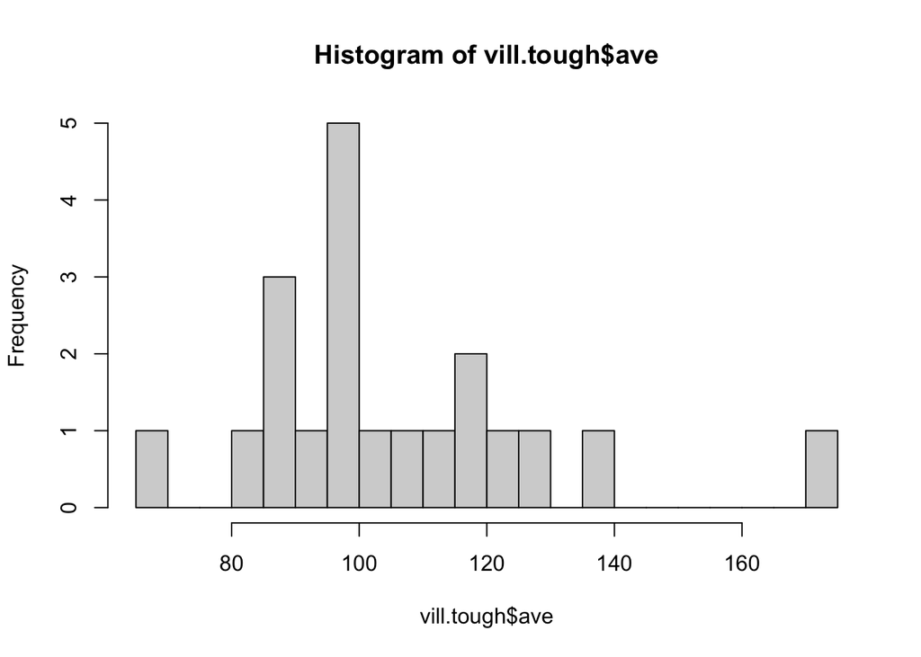

```r
hist(vill.tough$ave, breaks=20)
```

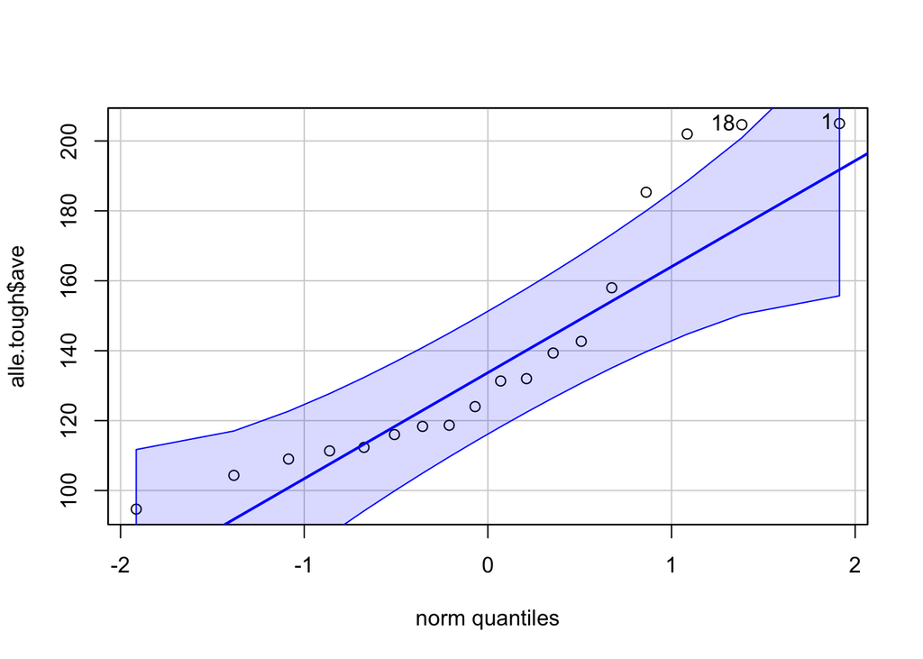

```
[1]  1 18
```

```r
# QQ plots of different fits
qqp(alle.tough$ave, "norm")
```

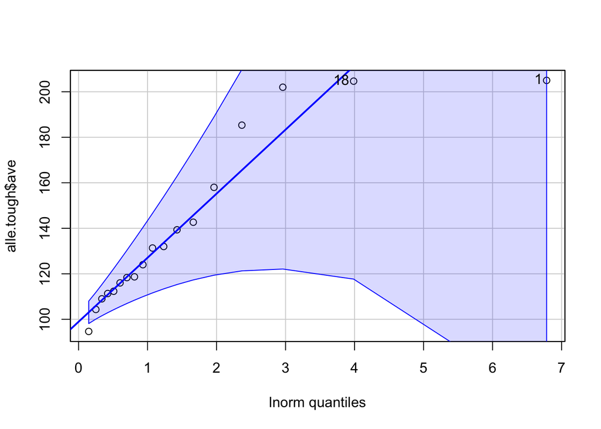

```
[1]  1 18
```

```r
qqp(alle.tough$ave, "lnorm") #best
```

```r
shapiro.test(log(alle.tough$ave))
```

```
    Shapiro-Wilk normality test

data:  log(alle.tough$ave)
W = 0.9019, p-value = 0.06202
```

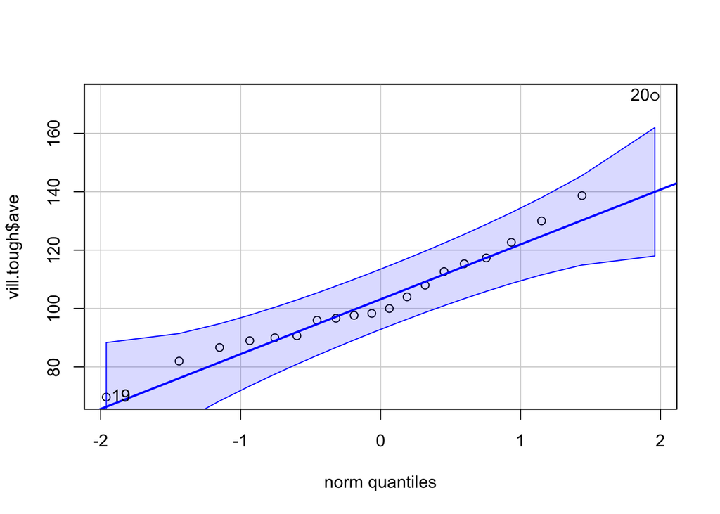

```
[1] 20 19
```

```r
qqp(vill.tough$ave, "norm")
```

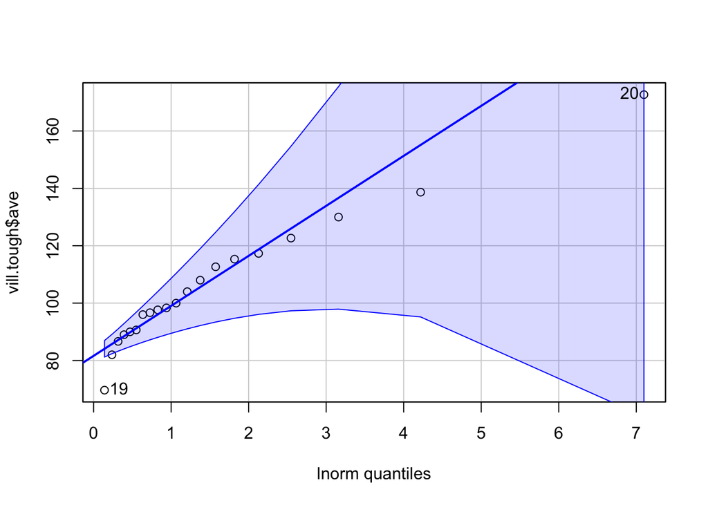

```
[1] 20 19
```

```r
qqp(vill.tough$ave, "lnorm") #best
```

```r
shapiro.test(log(vill.tough$ave)) # could be normal (not not normal)
```

```
    Shapiro-Wilk normality test

data:  log(vill.tough$ave)
W = 0.97175, p-value = 0.7912
```

```r
wilcox.test(tough$ave ~ tough$species, paired = F) #W = 294, p-value = 0.000566
```

```
    Wilcoxon rank sum exact test

data:  tough$ave by tough$species
W = 294, p-value = 0.000566
alternative hypothesis: true location shift is not equal to 0
```

```r
t.test(log(tough$ave) ~ tough$species, paired = F) # t = 3.6241, df = 33.24, p-value = 0.0009574
```

```
    Welch Two Sample t-test

data:  log(tough$ave) by tough$species
t = 3.6241, df = 33.24, p-value = 0.0009574
alternative hypothesis: true difference in means between group alle and group vill is not equal to 0
95 percent confidence interval:
 0.1166056 0.4148987
sample estimates:
mean in group alle mean in group vill
          4.907907           4.642155
```

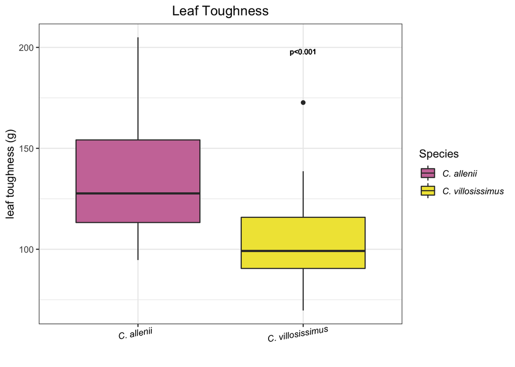

```r
# both say the same thing... which is better to use in the article?

# Plot leaf toughness
ggplot(data=tough, aes(x=species, y=ave)) +
  geom_boxplot(aes(fill = species)) +
  scale_fill_manual(values = c("#cc79a7", "#f0e442"), name = "Species",
                    labels=c("alle" = expression(italic("C. allenii")),
                             "vill" = expression(italic("C. villosissimus")))) +
  ggtitle("Leaf Toughness") +
  theme(plot.title = element_text(hjust = 0.5), legend.text.align = 0) +
  xlab("") +
  ylab("leaf toughness (g)")+
  scale_x_discrete(labels=c("alle" = expression(italic("C. allenii")),
                            "vill" = expression(italic("C. villosissimus")))) +
  theme(axis.text.x = element_text(angle = 10, hjust = 0.6, colour = "black")) +
  geom_text(x='vill', y=198, aes(label = "p<0.001"), size=2.5)
```

```r
#ggsave("leaf_toughness_plot.png", device = "png", width = 10, height = 7, units = "cm")
```